# Lab 043 — TabNet: implement sequential attention, then read the masks

## Follow the computation

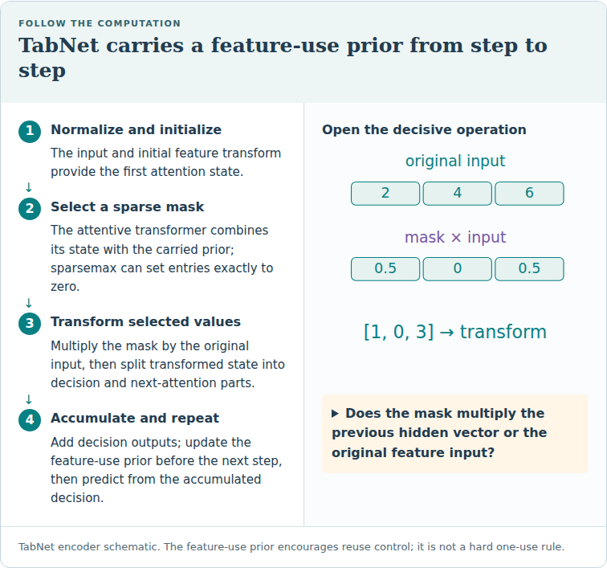

TabNet encoder schematic. The feature-use prior encourages reuse control; it is not a hard one-use rule.

**Trace question:** Does the mask multiply the previous hidden vector or the original feature input?

**Trace answer:** The feature mask selects the original feature input at each step. The attention state and prior govern that selection.

**Lesson:** `lessons/0043-tabnet.html` · **Phase / Year:** Year 2 · Q1

**Paper:** Arik & Pfister 2019, *TabNet: Attentive Interpretable Tabular Learning* ([arXiv:1908.07442](https://arxiv.org/abs/1908.07442)) — the architecture section (Fig. 4a–4d) + Appendix E/F. sparsemax: Martins & Astudillo 2016 ([arXiv:1602.02068](https://arxiv.org/abs/1602.02068)). Synthetic generators: Chen et al. 2018 ([arXiv:1802.07814](https://arxiv.org/abs/1802.07814)).

**Dataset tiers:** **C** (the paper's own synthetic Syn2/Syn4 — the only place mask claims are falsifiable) + **A** (small real OpenML tables via `relkit`).

**Skill you are practising:** implement TabNet's **sequential attention from scratch** — (1) `sparsemax`, (2) the **attentive transformer + prior scale** — then (3) **read its masks** on data whose relevant features are known, and (4) hold it to L042's **baseline-first rule** against the tuned MLP/ResNet.

**Exit criteria:** EXIT TICKET prints your sparsemax validation, the gamma = 1 ban property, the Syn2/Syn4 mask readings (one clean success, one partial), and the rank table with an honest verdict separating *"did not clear the bar"* from *"significantly worse"*.

### How this notebook works

- **PROVIDED** cells — boilerplate (data, frame, search spaces, GBDT/net searches) **and** the paper's encoder copied into the notebook (not hidden behind `import relkit.tabnet`); just run.
- **TODO** cells — blanks (`____`); you implement the skill.
- **CHECK** cells — immediate feedback; do not edit.
- Run top to bottom. After EXIT, a **NEXT STEP** cell trains closer to the paper (Colab GPU or Modal). When **EXIT TICKET** prints cleanly, paste it to your teacher or say *"lab done"*.

### Environment

One-time: `bash labs/setup-env.sh` → kernel **Relational Labs (.venv)**. Needs **torch** + scikit-learn (CPU is fine); `pytorch-tabnet` is optional and used only to validate your sparsemax. Real datasets fetch from OpenML on first run then cache. Budget: **~2–4 minutes on CPU** (measured: 126 s) — set `OMP_NUM_THREADS=1` if a search feels slow (that has been the real cause of every slow lab so far). This lab uses a deliberately small budget/seed/dataset count to stay interactive; the lesson's headline numbers come from the fuller `labs/_verify_l043.py` run plus the published benchmarks.

### Running on Google Colab?

Colab opens only this single file, so the course package (`relkit`) and the lab dependencies (xgboost, lightgbm, catboost, …) are **not** present by default. The cell below fixes that: on Colab it shallow-clones the course repo, installs `requirements-labs.txt`, and switches into `labs/` so `relkit` imports and the data cache resolve. **On a local venv or your own Jupyter it does nothing — just run it and continue.**

```python
# @colab-bootstrap — PROVIDED. Makes the lab self-sufficient on Google Colab; a no-op elsewhere.
import os, sys

if "google.colab" in sys.modules:
    if not os.path.isdir("/content/relational"):
        !git clone --depth 1 https://github.com/Avistian/relational.git /content/relational
    %pip install -q -r /content/relational/requirements-labs.txt
    os.chdir("/content/relational/labs")
    print("Colab ready — working dir:", os.getcwd())
else:
    print("Not on Colab — using the local environment as-is.")
```

## Concept recap — what TabNet actually does

**The idea.** Instead of feeding every feature into every layer, TabNet takes `N_steps` **decision steps**; at each step it *selects a sparse subset of features* to reason from, processes them, and adds its contribution to the prediction. Masking then transforming then summing is a soft, learned version of "split on this feature, then that one" — the tree-like inductive bias an MLP lacks (L025–L027).

**The four pieces.**

1. **sparsemax** (Task 1) — the projection onto the probability simplex. Subtract one threshold `tau`, clip negatives to zero, and whatever survives sums to 1. Unlike softmax it yields **exact zeros**, so a feature can be genuinely switched off (and gets no gradient at that step).
2. **Attentive transformer** (Task 2) — `M[i] = sparsemax(P[i-1] * h_i(a[i-1]))`, where `h_i` is `Linear -> BatchNorm`.
3. **Prior scale** (Task 2) — `P[i] = prod_j (gamma - M[j])`, starting at 1. This is the memory that makes the attention **sequential**: features already spent are discounted, so steps pick *different* ones. At `gamma = 1` a fully-used feature is banned outright; larger `gamma` permits reuse.
4. **Feature transformer** — `Linear -> GhostBatchNorm -> GLU` blocks (2 shared across steps + 2 step-dependent), wired with `sqrt(0.5)`-scaled residuals. Its output splits into `d[i]` (goes to the prediction, aggregated as `d_out = sum_i ReLU(d[i])`) and `a[i]` (feeds the next step's attention). After Task 2 the rest of the encoder is **inlined into this notebook** so you can read every line; you build pieces 1–3, which are the load-bearing ones.

Plus a **sparsity penalty** `L_sparse` (the masks' entropy, weight `lambda_sparse`) that pushes each step to commit to fewer features.

**Interpretability, and its limits.** `M_agg` aggregates the per-step masks weighted by each step's decision contribution `eta[i]`, giving a per-row feature attribution straight out of the forward pass — no separate SHAP/LIME run. Task 3 tests that claim where the answer is known, and finds it holds for **global** relevance and only **partially** for **instance-wise** relevance.

**The bar (Task 4).** Novel mechanism or not, it must beat a properly-tuned MLP/ResNet under the same protocol, or it has shown nothing (L042).

Full write-up + the interactive mask/prior widget: Lesson 043.

## Setup — PROVIDED (paper's synthetic data + real tables + shared frame + search spaces)

```python
# PROVIDED — imports, the paper's synthetic generators, the small real tables, the shared frame,
# and the search spaces. The TabNet *architecture* is inlined in a later cell so you can read it;
# `relkit` here is only data + L042 baselines + a sparsemax checker (NOTES #22 / #25).
# Just run this cell.
import warnings
warnings.filterwarnings("ignore")

import numpy as np
import torch
import torch.nn as nn
from scipy.stats import rankdata, friedmanchisquare
from sklearn.compose import ColumnTransformer
from sklearn.preprocessing import StandardScaler, OneHotEncoder
from sklearn.model_selection import train_test_split
from sklearn.metrics import roc_auc_score
from sklearn.ensemble import HistGradientBoostingClassifier

import sys
from pathlib import Path
sys.path.insert(0, str(Path(".").resolve()))          # labs/ when run from there
sys.path.insert(0, str(Path(".").resolve().parent))   # labs/ when run from labs/solutions/
from relkit import load_tier_a
from relkit.nets import TabResNet, TabMLP, train_net, net_auc     # L042 baselines (from scratch)
from relkit.tabnet import sparsemax as relkit_sparsemax           # checker only (NOTES #22)
from relkit.synth import make_syn2, make_syn4                      # the paper's Table 1 / Fig. 5 data

DEVICE = "cpu"
DATASETS = ["credit_g", "diabetes", "kc1"]   # small + numeric-heavy: NOT representative (see #23 note)
BUDGET, SEEDS = 3, [0, 1]                    # smaller than the lesson's run, so the lab stays interactive
EPOCHS, PATIENCE = 120, 12                   # same as labs/_verify_l043.py, so directions reproduce

def load_dense(name):
    Xdf, y = load_tier_a(name)
    num = Xdf.select_dtypes(include="number").columns.tolist()
    cat = [c for c in Xdf.columns if c not in num]
    ct = ColumnTransformer([("num", StandardScaler(), num),
                            ("cat", OneHotEncoder(handle_unknown="ignore", sparse_output=False), cat)])
    return ct.fit_transform(Xdf).astype(np.float32), y.to_numpy().astype(np.float32)

def frame(X, y, seed):
    """The SHARED frame — identical for every model (L020 contract, L042 protocol)."""
    Xtr_f, Xte, ytr_f, yte = train_test_split(X, y, test_size=0.30, random_state=seed, stratify=y)
    Xtr, Xva, ytr, yva = train_test_split(Xtr_f, ytr_f, test_size=0.25, random_state=seed,
                                          stratify=ytr_f)
    return Xtr, ytr, Xva, yva, Xte, yte

# ---- per-model search SPACES (equal BUDGET is what makes this fair — L038)
def sample_tabnet(rng, d_in):
    """TabNet's space, from the paper's Appendix F."""
    u = int(rng.choice([8, 16, 24]))
    return dict(d_in=d_in, n_d=u, n_a=u, n_steps=int(rng.choice([3, 4, 5])),
                gamma=float(rng.choice([1.0, 1.2, 1.5, 2.0])),
                lambda_sparse=float(rng.choice([0.0, 1e-6, 1e-4, 1e-3, 1e-2])),
                virtual_batch_size=int(rng.choice([64, 128])),
                momentum=0.02), dict(lr=float(rng.choice([0.005, 0.01, 0.02, 0.025])))

def sample_net(kind, rng, d_in):
    opt = dict(lr=float(10 ** rng.uniform(-3.3, -2.5)), wd=float(10 ** rng.uniform(-6, -3)))
    if kind == "resnet":
        dm = int(rng.choice([64, 128, 192]))
        cfg = dict(d_in=d_in, d_main=dm, d_hidden=int(dm * rng.choice([1.0, 2.0])),
                   n_blocks=int(rng.choice([1, 2, 3])), dropout1=float(rng.uniform(0.0, 0.3)),
                   dropout2=float(rng.uniform(0.0, 0.3)))
    else:
        cfg = dict(d_in=d_in, d_block=int(rng.choice([64, 128, 256])),
                   n_blocks=int(rng.choice([1, 2, 3])), dropout=float(rng.uniform(0.0, 0.4)))
    return cfg, opt

def search_net(kind, Xtr, ytr, Xva, yva, Xte, yte, *, budget, seed):
    rng = np.random.default_rng(seed)
    best = {"val": -1.0, "test": None}
    for t in range(budget):
        cfg, opt = sample_net(kind, rng, Xtr.shape[1])
        m = TabResNet(**cfg) if kind == "resnet" else TabMLP(**cfg)
        m, val = train_net(m, Xtr, ytr, Xva, yva, lr=opt["lr"], wd=opt["wd"],
                           max_epochs=EPOCHS, patience=PATIENCE, seed=seed + t)
        if val > best["val"]:
            best = {"val": val, "test": net_auc(m, Xte, yte)}
    return best["test"]

def search_gbt(Xtr, ytr, Xva, yva, Xte, yte, *, budget, seed):
    rng = np.random.default_rng(seed + 999)
    best = {"val": -1.0, "test": None}
    for _ in range(budget):
        clf = HistGradientBoostingClassifier(
            random_state=seed, max_iter=400,
            learning_rate=float(10 ** rng.uniform(-1.5, -0.7)),
            max_leaf_nodes=int(rng.choice([15, 31, 63])),
            l2_regularization=float(rng.uniform(0.0, 3.0))).fit(Xtr, ytr)
        val = roc_auc_score(yva, clf.predict_proba(Xva)[:, 1])
        if val > best["val"]:
            best = {"val": val, "test": roc_auc_score(yte, clf.predict_proba(Xte)[:, 1])}
    return best["test"]

print("setup ok — torch", torch.__version__)
```

## Task 1 — implement `sparsemax` (the reason a mask can contain real zeros)

**Goal.** Write the projection onto the probability simplex from **Algorithm 1** of Martins & Astudillo (2016), the operation TabNet uses instead of softmax.

**Why this first.** A *selection* mask must be able to say "not this feature" — an exact **0**. Softmax never can: `exp(z)` is strictly positive, so every feature leaks a little weight through and keeps receiving gradient. sparsemax returns the closest point on the simplex, which usually lies on a face where some coordinates are exactly zero. That single change is what makes TabNet's masks *selections* rather than *weightings*.

The algorithm, for a vector `z` of length K:

```
1. sort descending:  z_(1) >= z_(2) >= ... >= z_(K)
2. k(z) = max{ k : k * z_(k) > (sum_{j<=k} z_(j)) - 1 }
3. tau   = ( (sum_{j<=k(z)} z_(j)) - 1 ) / k(z)
4. out_i = max(z_i - tau, 0)
```

Read step 3 as: *one* threshold, chosen so that whatever survives sums to exactly 1.

```python
# TODO — implement sparsemax along the last dimension. Fill every ____.
def sparsemax(z):
    """z: (B, K) tensor -> (B, K) projection onto the simplex (exact zeros allowed)."""
    z = z - z.max(dim=-1, keepdim=True).values   # no-op for the projection; keeps the prefix sums well-scaled
    z_sorted, _ = torch.sort(z, dim=-1, descending=True)
    K = z.size(-1)
    arange = torch.arange(1, K + 1, device=z.device, dtype=z.dtype)

    # cumulative sums minus 1  ->  (sum_{j<=k} z_(j)) - 1
    cssv = ____

    # step 2: which prefix lengths k satisfy  k * z_(k) > cssv_k ?
    support = ____

    # k(z) = how many satisfy it (keepdim so it can index)
    k = support.to(z.dtype).sum(dim=-1, keepdim=True)

    # step 3: tau = cssv at position k(z), divided by k(z)
    tau = ____

    # step 4: shift and clip
    return ____

zz = torch.tensor([[3.0, 1.2, 0.9, -2.0], [0.5, 0.5, 0.5, 0.5]])
print("sparsemax:\n", sparsemax(zz))
print("softmax:  \n", torch.softmax(zz, dim=-1))
```

```python
# CHECK — the properties that make sparsemax usable as a selection mask (do not edit)
rng = np.random.default_rng(0)
Z = torch.tensor(rng.normal(size=(200, 12)) * 3, dtype=torch.float64)
P = sparsemax(Z)

ok = True
def chk(name, cond, detail=""):
    global ok
    print(("PASS  " if cond else "FAIL  ") + name + (f"   [{detail}]" if detail else ""))
    if not cond: ok = False

chk("sums to 1 along the feature axis", torch.allclose(P.sum(-1), torch.ones(200, dtype=torch.float64)),
    f"max dev {(P.sum(-1) - 1).abs().max():.2e}")
chk("non-negative", bool((P >= 0).all()))
chk("contains EXACT zeros (softmax never does)", bool((P == 0).any()) and bool((torch.softmax(Z, -1) > 0).all()),
    f"{(P == 0).double().mean() * 100:.0f}% of entries are 0")
chk("uniform input -> uniform output",
    torch.allclose(sparsemax(torch.zeros(1, 5, dtype=torch.float64)),
                   torch.full((1, 5), 0.2, dtype=torch.float64)))
chk("dominant coordinate -> one-hot",
    torch.allclose(sparsemax(torch.tensor([[9.0, 0.0, 0.0]], dtype=torch.float64)),
                   torch.tensor([[1.0, 0.0, 0.0]], dtype=torch.float64)))

# VALIDATION against the reference implementation (NOTES #22): the library checks you.
try:
    from pytorch_tabnet.sparsemax import Sparsemax
    ref = Sparsemax(dim=-1)(Z.float())
    d = (P.float() - ref).abs().max().item()
    chk("VALIDATED against pytorch_tabnet.sparsemax", d < 1e-5, f"max |Δ| {d:.2e}")
except ImportError:
    print("SKIP  reference pytorch_tabnet not installed (pip install pytorch-tabnet)")

# ...and against relkit's version, which the rest of the lab uses
chk("agrees with relkit.tabnet.sparsemax",
    torch.allclose(P, relkit_sparsemax(Z), atol=1e-9))
print("\nTask 1", "OK" if ok else "-- fix the FAILs above")
```

## Task 2 — the attentive transformer and the prior scale (the *sequential* part)

**Goal.** Build the block that produces each step's mask, and the running prior that couples the steps:

```
M[i] = sparsemax( P[i-1] * h_i(a[i-1]) )        h_i = Linear -> BatchNorm
P[i] = prod_{j<=i} ( gamma - M[j] )             P[0] = 1
```

**Why this matters.** Sparsity and *sequentiality* are two different things. sparsemax (Task 1) gives you sparsity. The **prior scale** is what makes the attention sequential: it remembers how much each feature has already been spent and multiplies the next step's logits by it, so a feature used early is discounted and the steps divide the features between them instead of all grabbing the same strong ones.

`gamma` is the strictness knob, and you will verify its defining property: at **gamma = 1** the leftover budget is exactly `1 - M`, so a feature used *in full* is banned from every later step.

```python
# TODO — fill every ____.
class AttentiveTransformer(nn.Module):
    """M[i] = sparsemax(P[i-1] * h_i(a[i-1])), with h_i = Linear -> BatchNorm."""
    def __init__(self, d_a, d_features):
        super().__init__()
        self.fc = nn.Linear(d_a, d_features, bias=False)
        self.bn = nn.BatchNorm1d(d_features)

    def forward(self, a, prior):
        logits = self.bn(self.fc(a))
        # scale the logits by the prior, then project onto the simplex
        return ____

def update_prior(prior, M, gamma):
    """P[i] = P[i-1] * (gamma - M[i]).  Clamp at 0: a prior can never go negative."""
    return ____

# A 3-step run on one batch, to watch the prior work.
torch.manual_seed(0)
B, D, d_a, gamma = 64, 10, 8, 1.5
att = [AttentiveTransformer(d_a, D).eval() for _ in range(3)]
a = torch.randn(B, d_a)
prior = torch.ones(B, D)
masks, priors = [], []
with torch.no_grad():                    # inspecting the mechanism, not training it
    for i in range(3):
        priors.append(prior.clone())
        M = att[i](a, prior)
        masks.append(M)
        prior = update_prior(prior, M, gamma)
        a = torch.randn(B, d_a)      # stand-in for the real a[i] from the feature transformer

for i, M in enumerate(masks):
    print(f"M[{i+1}] row 0:", np.round(M[0].numpy(), 3),
          " nonzero:", int((M[0] > 0).sum()))
print("P[2] row 0:", np.round(priors[2][0].numpy(), 3), "  (untouched features sit at gamma^2)")
```

```python
# CHECK — the paper's invariants for the mask and the prior (do not edit)
ok = True
def chk(name, cond, detail=""):
    global ok
    print(("PASS  " if cond else "FAIL  ") + name + (f"   [{detail}]" if detail else ""))
    if not cond: ok = False

chk("every mask sums to 1 per row",
    all(torch.allclose(M.sum(-1), torch.ones(B), atol=1e-5) for M in masks))
chk("masks are sparse (exact zeros present)", any(bool((M == 0).any()) for M in masks),
    f"step 1: {(masks[0] == 0).float().mean() * 100:.0f}% zeros")
chk("P[0] is all ones (no prior on any feature)", bool((priors[0] == 1).all()))
chk("P[1] == gamma - M[1] exactly",
    torch.allclose(priors[1], torch.clamp(gamma - masks[0], min=0), atol=1e-6))
chk("a spent feature's prior drops BELOW gamma, an untouched one stays at gamma",
    bool(((priors[1] < gamma - 1e-6) == (masks[0] > 0)).all()))

# gamma = 1: the defining property — full use bans the feature outright.
prior1 = torch.ones(1, 4)
M_full = torch.tensor([[1.0, 0.0, 0.0, 0.0]])       # feature 0 used in full
p_after = update_prior(prior1, M_full, 1.0)
chk("gamma = 1: a fully-used feature is BANNED (prior exactly 0)", float(p_after[0, 0]) == 0.0,
    f"prior after = {p_after[0].tolist()}")
p_after_relaxed = update_prior(prior1, M_full, 2.0)
chk("gamma = 2: the same feature stays available (prior > 0)", float(p_after_relaxed[0, 0]) > 0,
    f"prior after = {p_after_relaxed[0].tolist()}")
chk("priors never go negative", all(bool((p >= 0).all()) for p in priors))
print("\nTask 2", "OK" if ok else "-- fix the FAILs above")
```

## The rest of the paper's architecture — inlined, not imported

The next cell is `labs/relkit/tabnet.py` copied into this notebook so you can **read every line** of Ghost BN, the GLU feature transformer, the encoder, and the training loop. It is not `from relkit import ...` hiding a model behind a package. `sparsemax` defined in your TODO cells above are **kept** — this copy skips those names, so the encoder you train next calls *your* functions.

`relkit/` still holds the canonical file for Modal / `_verify` so the two cannot drift in opposite directions; the notebook is a readable copy, not a black box.

```python
# PROVIDED — adapter: your Task-1 sparsemax is last-axis only; the inlined encoder calls dim=-1.
# Bind `_impl` at def-time (and stash it) so re-running this cell cannot wrap the wrapper —
# that RecursionError's on the next train, not here.
_impl = getattr(sparsemax, "_impl", sparsemax)
def sparsemax(z, dim=-1, *, _impl=_impl):
    """Keep YOUR Task-1 implementation; accept the encoder's dim= keyword."""
    if dim in (-1, z.ndim - 1):
        return _impl(z)
    z_t = z.transpose(dim, -1)
    return _impl(z_t).transpose(dim, -1)
sparsemax._impl = _impl
```

```python
# PROVIDED — inlined from `labs/relkit/tabnet.py` so you can read every line.
# This is the paper implementation, not `import relkit...` hiding it.
# Canonical file stays at labs/relkit/tabnet.py for Modal / _verify; this cell is a copy.

"""From-scratch TabNet (Arik & Pfister 2019, arXiv:1908.07442) — Lesson 043.

Built from the paper, not from a library (NOTES standards #18/#22/#24). `pytorch_tabnet` is used only
as a VALIDATION point in `labs/_verify_l043.py`.

Paper map — every piece below cites the element it realises:

| Paper                        | Here                                        |
|------------------------------|---------------------------------------------|
| sparsemax (Martins 2016 Alg. 1) | `sparsemax`                              |
| Ghost BN (Fig. 4c, Hoffer 2017) | `GhostBatchNorm`                         |
| FC -> BN -> GLU (Fig. 4c)       | `GLUBlock`                               |
| Feature transformer (Fig. 4c)   | `FeatureTransformer`                     |
| M[i] = sparsemax(P[i-1] * h_i(a[i-1])) (Fig. 4d) | `AttentiveTransformer`  |
| P[i] = prod_j (gamma - M[j])    | `TabNetEncoder.forward` (`prior`)        |
| L_sparse = sum -M log(M+eps) / (N_steps*B) | `TabNetEncoder.forward` (`m_loss`) |
| d_out = sum_i ReLU(d[i])        | `TabNetEncoder.forward` (`d_out`)        |
| M_agg (eta-weighted masks)      | `TabNetEncoder.forward` (`M_agg`)        |

Binary classification only (one logit) — that is all the Lesson 043 lab needs. CPU is fine for the
small Tier-A tables.
"""
from __future__ import annotations

import math

import numpy as np
import torch
import torch.nn as nn
import torch.nn.functional as F
from sklearn.metrics import roc_auc_score


class GhostBatchNorm(nn.Module):
    """BatchNorm over virtual sub-batches of size `virtual_batch_size` (Hoffer et al. 2017).

    TabNet trains with very large batches (Appendix F: 1-10% of the training set). Normalising the
    whole batch at once would average away too much noise, so the batch is split into virtual batches
    and each is normalised on its own statistics. The paper keeps ordinary BN on the input features and
    uses ghost BN everywhere inside the blocks.

    NOTE on momentum: the paper's m_B (0.6-0.98) is TensorFlow-style *decay*. PyTorch's `momentum` is
    the complement, so pass `1 - m_B`.
    """

    def __init__(self, dim: int, virtual_batch_size: int = 128, momentum: float = 0.02):
        super().__init__()
        self.virtual_batch_size = virtual_batch_size
        self.bn = nn.BatchNorm1d(dim, momentum=momentum)

    def forward(self, x):
        if self.training and x.size(0) > self.virtual_batch_size:
            n_chunks = math.ceil(x.size(0) / self.virtual_batch_size)
            return torch.cat([self.bn(chunk) for chunk in x.chunk(n_chunks, dim=0)], dim=0)
        return self.bn(x)


class GLUBlock(nn.Module):
    """FC -> (ghost) BN -> GLU, the unit the feature transformer is stacked from (Fig. 4c).

    The FC layer emits `2 * d_out` values; GLU (Dauphin et al. 2016) splits them and computes
    `a * sigmoid(b)`, so half the activations act as a learned gate on the other half. The paper's
    ablation (Table 11) shows GLU beating ReLU here.

    `shared_linear` lets a layer be shared across all decision steps (parameter efficiency, Fig. 4c).
    """

    def __init__(self, d_in, d_out, *, shared_linear=None, virtual_batch_size=128, momentum=0.02):
        super().__init__()
        self.fc = shared_linear if shared_linear is not None else nn.Linear(d_in, 2 * d_out, bias=False)
        self.bn = GhostBatchNorm(2 * d_out, virtual_batch_size, momentum)

    def forward(self, x):
        x = self.bn(self.fc(x))
        a, b = x.chunk(2, dim=-1)
        return a * torch.sigmoid(b)


class FeatureTransformer(nn.Module):
    """Shared + step-dependent GLU blocks with sqrt(0.5)-normalised residuals (Fig. 4c).

    The paper's default is 2 shared layers (same weights at every decision step, since every step sees
    the same features) followed by 2 step-dependent layers. Residual connections are scaled by
    sqrt(0.5) so the variance does not grow as blocks are stacked (Gehring et al. 2017).

    The first block changes width (D -> n_d + n_a) so it has no residual.
    """

    SCALE = math.sqrt(0.5)

    def __init__(self, d_in, d_out, shared_linears, *, n_independent=2,
                 virtual_batch_size=128, momentum=0.02):
        super().__init__()
        blocks, d = [], d_in
        for lin in shared_linears:
            blocks.append(GLUBlock(d, d_out, shared_linear=lin,
                                   virtual_batch_size=virtual_batch_size, momentum=momentum))
            d = d_out
        for _ in range(n_independent):
            blocks.append(GLUBlock(d, d_out, virtual_batch_size=virtual_batch_size, momentum=momentum))
            d = d_out
        self.blocks = nn.ModuleList(blocks)

    def forward(self, x):
        for i, block in enumerate(self.blocks):
            out = block(x)
            x = out if i == 0 else (x + out) * self.SCALE
        return x


class AttentiveTransformer(nn.Module):
    """M[i] = sparsemax(P[i-1] * h_i(a[i-1]))  (Fig. 4d).

    `h_i` is one FC layer + ghost BN. The prior scale `P[i-1]` multiplies the logits, so a feature that
    has already been spent at earlier steps is pushed down and sparsemax is likely to zero it out.
    """

    def __init__(self, d_a, d_features, *, virtual_batch_size=128, momentum=0.02):
        super().__init__()
        self.fc = nn.Linear(d_a, d_features, bias=False)
        self.bn = GhostBatchNorm(d_features, virtual_batch_size, momentum)

    def forward(self, a, prior):
        return sparsemax(prior * self.bn(self.fc(a)), dim=-1)


class TabNetEncoder(nn.Module):
    """TabNet encoder for binary classification (Fig. 4a).

    Args mirror the paper's names: `n_d` (N_d, decision width), `n_a` (N_a, attention width),
    `n_steps` (N_steps), `gamma` (relaxation), `lambda_sparse`.

    forward returns `(logits, info)` where `info` carries the per-step masks, the aggregate importance
    mask `M_agg`, and the sparsity loss `m_loss` — the interpretability outputs Lesson 043 reads.
    """
```

```python
    def __init__(self, d_in, *, n_d=8, n_a=8, n_steps=3, gamma=1.3, lambda_sparse=1e-3,
                 n_shared=2, n_independent=2, virtual_batch_size=128, momentum=0.02, epsilon=1e-15):
        super().__init__()
        self.d_in, self.n_d, self.n_a, self.n_steps = d_in, n_d, n_a, n_steps
        self.gamma, self.lambda_sparse, self.epsilon = gamma, lambda_sparse, epsilon

        # Ordinary BN on the raw input features (the paper deliberately does NOT ghost-BN these).
        self.initial_bn = nn.BatchNorm1d(d_in, momentum=0.01)

        d_split = n_d + n_a
        # Shared FC layers: reused by the initial transformer AND every step's transformer (Fig. 4c).
        shared = []
        for i in range(n_shared):
            shared.append(nn.Linear(d_in if i == 0 else d_split, 2 * d_split, bias=False))
        self.shared_linears = nn.ModuleList(shared)

        ft_kwargs = dict(n_independent=n_independent, virtual_batch_size=virtual_batch_size,
                         momentum=momentum)
        # Step 0 has no mask yet: an initial transformer produces a[0] to seed the first attention.
        self.initial_transformer = FeatureTransformer(d_in, d_split, shared, **ft_kwargs)
        self.step_transformers = nn.ModuleList(
            [FeatureTransformer(d_in, d_split, shared, **ft_kwargs) for _ in range(n_steps)])
        self.attentive = nn.ModuleList(
            [AttentiveTransformer(n_a, d_in, virtual_batch_size=virtual_batch_size, momentum=momentum)
             for _ in range(n_steps)])
        self.final = nn.Linear(n_d, 1, bias=False)

    def forward(self, x, *, return_masks: bool = False):
        x = self.initial_bn(x)
        prior = torch.ones_like(x)                       # P[0] = 1 (no prior on any feature)
        a = self.initial_transformer(x)[:, self.n_d:]    # a[0]
        d_out = torch.zeros(x.size(0), self.n_d, device=x.device, dtype=x.dtype)
        m_loss = torch.zeros((), device=x.device, dtype=x.dtype)
        masks, etas = [], []

        for step in range(self.n_steps):
            M = self.attentive[step](a, prior)           # M[i]
            # L_sparse: entropy of the mask, summed over features, averaged over batch and steps.
            m_loss = m_loss + (-M * torch.log(M + self.epsilon)).sum(dim=1).mean() / self.n_steps
            prior = prior * (self.gamma - M)             # P[i] = prod_j (gamma - M[j])

            out = self.step_transformers[step](M * x)    # f_i(M[i] . f)
            d = F.relu(out[:, :self.n_d])                # d[i], ReLU per the decision aggregation
            a = out[:, self.n_d:]                        # a[i] feeds the next step's attention
            d_out = d_out + d
            if return_masks:
                masks.append(M)
                etas.append(d.sum(dim=1, keepdim=True))  # eta_b[i] = sum_c ReLU(d_b,c[i])

        logits = self.final(d_out).squeeze(-1)
        info = {"m_loss": m_loss}
        if return_masks:
            stacked_eta = torch.stack(etas, dim=0)               # steps x B x 1
            stacked_M = torch.stack(masks, dim=0)                # steps x B x D
            agg = (stacked_eta * stacked_M).sum(dim=0)           # B x D
            info.update(masks=[m.detach() for m in masks],
                        etas=[e.detach() for e in etas],
                        M_agg=(agg / agg.sum(dim=1, keepdim=True).clamp_min(1e-12)).detach())
        return logits, info


def train_tabnet(model, Xtr, ytr, Xva, yva, *, lr=2e-2, wd=0.0, max_epochs=120, patience=15,
                 batch_size=1024, decay_rate=0.9, decay_every=20, device="cpu", seed=0):
    """Mini-batch Adam training with early stopping on validation ROC-AUC.

    Same fair-protocol contract as `relkit.nets.train_net` (L042): the model picks its own training
    length by validation, so no arm is accidentally under- or over-trained. Two TabNet-specific pieces
    from the paper: the sparsity penalty `lambda_sparse * m_loss` is added to the loss, and the learning
    rate decays geometrically (Appendix F: "initially large learning rate ... gradually decayed").

    Returns (model_with_best_val_weights, best_val_auc).
    """
    torch.manual_seed(seed)
    model = model.to(device)
    opt = torch.optim.Adam(model.parameters(), lr=lr, weight_decay=wd)
    sched = torch.optim.lr_scheduler.StepLR(opt, step_size=decay_every, gamma=decay_rate)
    lossf = nn.BCEWithLogitsLoss()

    Xt = torch.tensor(np.asarray(Xtr), dtype=torch.float32, device=device)
    yt = torch.tensor(np.asarray(ytr), dtype=torch.float32, device=device)
    Xv = torch.tensor(np.asarray(Xva), dtype=torch.float32, device=device)
    n = Xt.size(0)
    bs = min(batch_size, n)
    generator = torch.Generator().manual_seed(seed)

    best_auc, best_state, since = -1.0, None, 0
    for _ in range(max_epochs):
        model.train()
        perm = torch.randperm(n, generator=generator)
        for start in range(0, n, bs):
            idx = perm[start:start + bs]
            if idx.numel() < 2:      # BatchNorm needs >1 row
                continue
            opt.zero_grad()
            logits, info = model(Xt[idx])
            loss = lossf(logits, yt[idx]) + model.lambda_sparse * info["m_loss"]
            loss.backward()
            opt.step()
        sched.step()

        model.eval()
        with torch.no_grad():
            pv = torch.sigmoid(model(Xv)[0]).cpu().numpy()
        val_auc = roc_auc_score(yva, pv)
        if val_auc > best_auc:
            best_auc, since = val_auc, 0
            best_state = {k: v.detach().clone() for k, v in model.state_dict().items()}
        else:
            since += 1
            if since >= patience:
                break
    if best_state is not None:
        model.load_state_dict(best_state)
    return model, best_auc


@torch.no_grad()
def tabnet_auc(model, X, y, *, device="cpu"):
    model.eval()
    logits, _ = model(torch.tensor(np.asarray(X), dtype=torch.float32, device=device))
    return roc_auc_score(y, torch.sigmoid(logits).cpu().numpy())
```

```python
@torch.no_grad()
def explain(model, X, *, device="cpu"):
    """Return (M_agg, per-step masks) for rows `X` — the paper's local/global interpretability outputs."""
    model.eval()
    _, info = model(torch.tensor(np.asarray(X), dtype=torch.float32, device=device), return_masks=True)
    return info["M_agg"].cpu().numpy(), [m.cpu().numpy() for m in info["masks"]]
```